# Homework Assignment 1

Arshaq Razack

Assigned: Oct 24, 2020, Due Sun Nov 01, 2020 11:59PM

# Data Exploration

```r
nyc = read.csv("nycflights.csv")

# Delete first column
nyc$X = NULL

# Factorizing variables
nyc$origin = as.factor(nyc$origin)
nyc$tailnum = as.factor(nyc$tailnum)
nyc$month = as.factor(nyc$month)
nyc$dest = as.factor(nyc$dest)
nyc$carrier = as.factor(nyc$carrier)
nyc$flight = as.factor(nyc$flight)
```

- How many airlines are there?

There are 16 airlines

- How many flights there were by the airline with code `OO`? (Hint: `nrow` can be useful here along with logical indexing)

There are 32 flights by the airline with code 00

- How long is the shortest flight out of any NYC airport? (Hint: `min` can be useful, remember to handle `NA` values)

Shortest flight out of NYC airport is 20 mins long

- How many flights where there by United Airlines (code: UA) on Jan 12th 2013?

There were 112 flights by UA on Jan 12th 2013

### Arrival Delay

```r
janflight = nyc[nyc$month == "1",] #Filtering Jan details
```

- What was the average arrival delay for all airports and all airlines combined in Jan 2013?

Average arrival delay for all airports and all airlines combined in Jan 2013 is 6.13

- Whats was the median arrival delay for all airports and all airlines combined in Jan 2013?

Median arrival delay for all airports and all airlines combined in Jan 2013 is -3

- Based on your answers to the two questions above, what can you say about the distribution of arrival delays?

While most airlines and flights arrive ahead of time (hence median is negative), when flights do get delayed, they get delayed by a huge amount which is pulling the average delay greater than 0

### Airline Performance

- Calculate average arrival delays by airline

```r
#Calculating delays by airline
delay = round(tapply(nyc$arr_delay, nyc$carrier, mean, na.rm=TRUE),2)
```

Average arrival delays by airline as as per below

```r
data.frame(delay)
```

```
##    delay
## 9E  7.38
## AA  0.36
## AS -9.93
## B6  9.46
## DL  1.64
## EV 15.80
## F9 21.92
## FL 20.12
## HA -6.92
## MQ 10.77
## OO 11.93
## UA  3.56
## US  2.13
## VX  1.76
## WN  9.65
## YV 15.56
```

- Draw a Bar Plot of Average Arrival Delays for all the Airlines

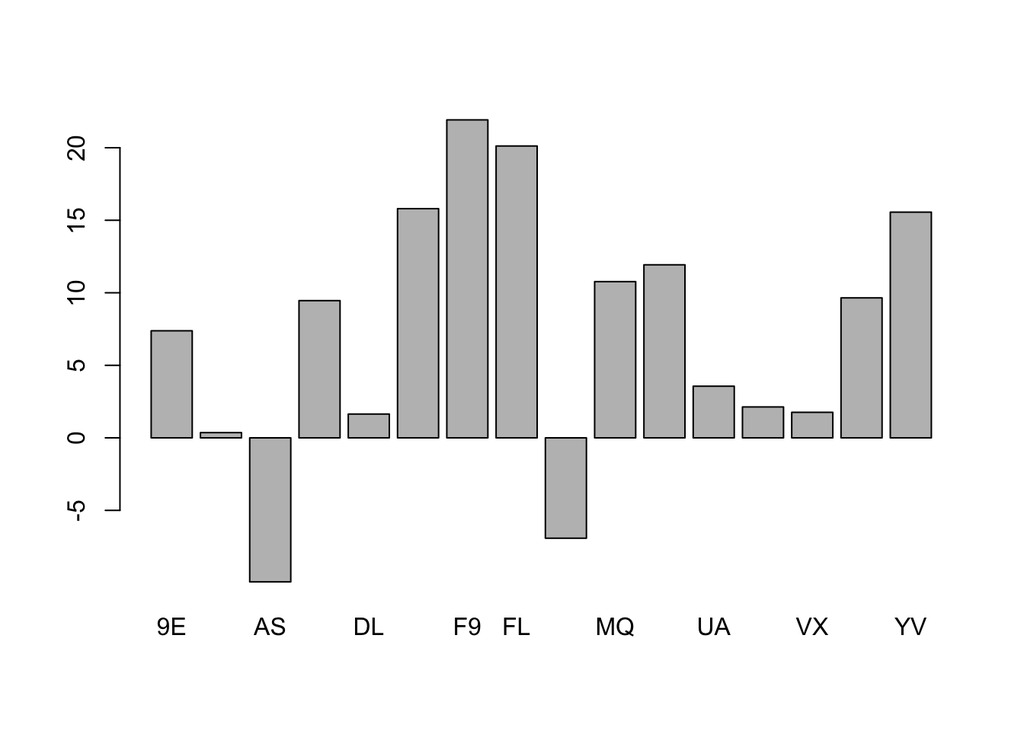

```r
barplot(delay)
```

- Which airline has the highest average arrival delay? Which airline has the smallest average arrival delay? Are there airlines that actually have negative average delay?

Airline with the highest average delay is F9 and the smallest average delay is AS. Airlines with negative average delay are AS, HA

### Air Gain

```r
#Creating column Air Gain
nyc$airgain <- nyc$dep_delay - nyc$arr_delay
```

1. Explore airgain data - calculate suitable descriptive statistics and appropriate graphics to better understand this data. This part is open ended - you do what you feel works best for you.

```r
library(ggplot2)
summary(nyc$airgain)
```

```
##    Min. 1st Qu.  Median    Mean 3rd Qu.    Max.    NA's
## -196.00   -3.00    7.00    5.66   17.00  109.00    9430
```

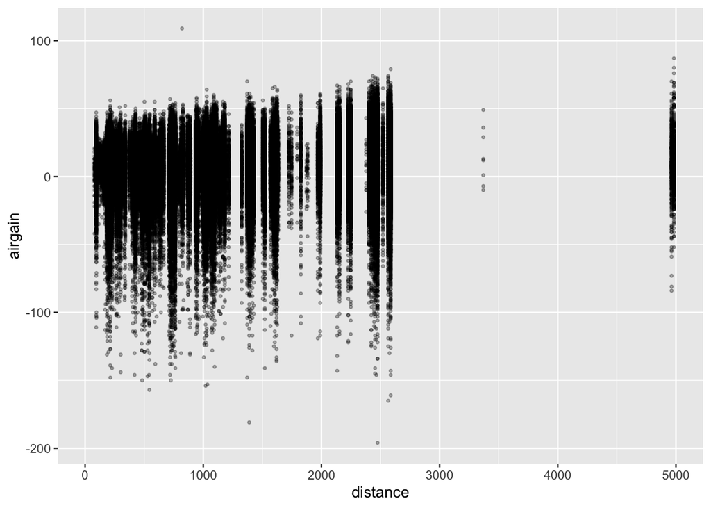

```r
#Examining airgain for different airlines
airgain_airline <- round(tapply(nyc$airgain, nyc$carrier, mean, na.rm=TRUE),2)
#Examining relationship between distance & airgain - airgain is widely distributed with increase in distance
baseplot <- ggplot(data=nyc, aes(x=distance, y=airgain))
baseplot + geom_point(size=0.7, alpha=0.3)
```

- do airlines actually gain any time when in air on average?

Average airgain is 5.66 and Yes, airlines gain time in air on average

- Calculate average airgain for different airlines - which airlines do a better job, which do a worse job?

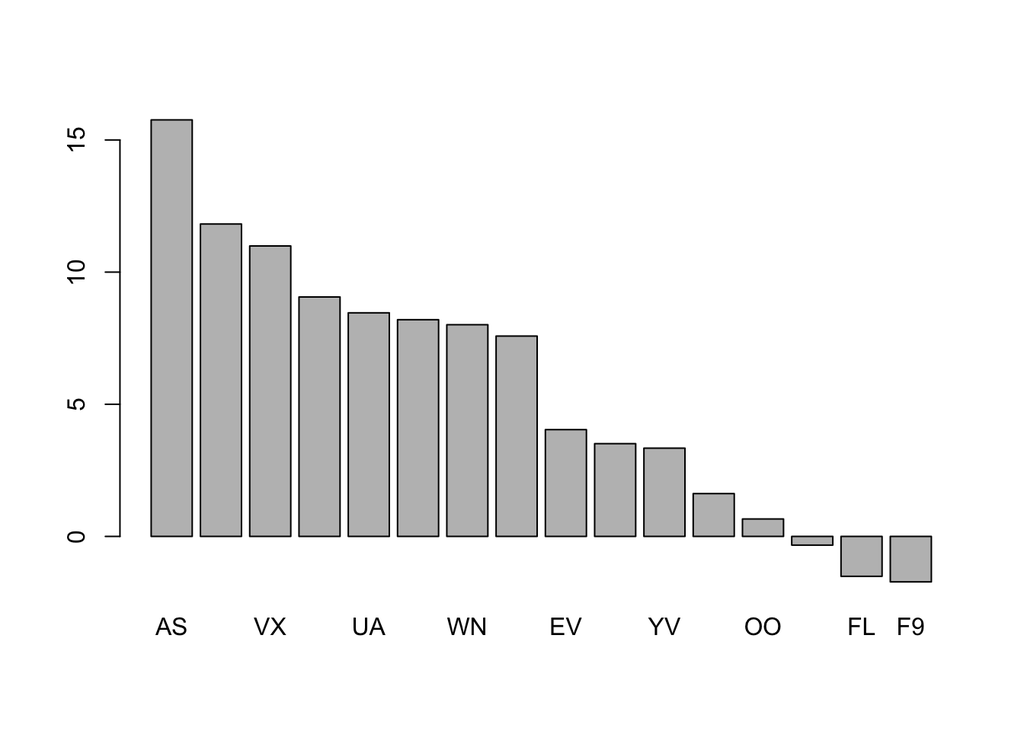

```r
#Airlines in decreasing order of airgain
barplot(sort(airgain_airline,decreasing=TRUE))
```

### Merging Data Frames

1. Read the `planes.csv` file using `read.csv` command. Do any data cleaning necessary.

```r
#Reading planes data and cleaning
planes <- read.csv("planes.csv")
summary(planes)
```

```
##        X            tailnum               year          type
##  Min.   :   1.0   Length:3322        Min.   :1956   Length:3322
##  1st Qu.: 831.2   Class :character   1st Qu.:1997   Class :character
##  Median :1661.5   Mode  :character   Median :2001   Mode  :character
##  Mean   :1661.5                      Mean   :2000
##  3rd Qu.:2491.8                      3rd Qu.:2005
##  Max.   :3322.0                      Max.   :2013
##                                      NA's   :70
##  manufacturer          model              engines          seats
##  Length:3322        Length:3322        Min.   :1.000   Min.   :  2.0
##  Class :character   Class :character   1st Qu.:2.000   1st Qu.:140.0
##  Mode  :character   Mode  :character   Median :2.000   Median :149.0
##                                        Mean   :1.995   Mean   :154.3
##                                        3rd Qu.:2.000   3rd Qu.:182.0
##                                        Max.   :4.000   Max.   :450.0
##
##      speed          engine
##  Min.   : 90.0   Length:3322
##  1st Qu.:107.5   Class :character
##  Median :162.0   Mode  :character
##  Mean   :236.8
##  3rd Qu.:432.0
##  Max.   :432.0
##  NA's   :3299
```

```r
str(planes)
```

```
## 'data.frame':    3322 obs. of  10 variables:
##  $ X           : int  1 2 3 4 5 6 7 8 9 10 ...
##  $ tailnum     : chr  "N10156" "N102UW" "N103US" "N104UW" ...
##  $ year        : int  2004 1998 1999 1999 2002 1999 1999 1999 1999 1999 ...
##  $ type        : chr  "Fixed wing multi engine" "Fixed wing multi engine" "Fixed wing multi engine" "Fixed wing multi engine" ...
##  $ manufacturer: chr  "EMBRAER" "AIRBUS INDUSTRIE" "AIRBUS INDUSTRIE" "AIRBUS INDUSTRIE" ...
##  $ model       : chr  "EMB-145XR" "A320-214" "A320-214" "A320-214" ...
##  $ engines     : int  2 2 2 2 2 2 2 2 2 2 ...
##  $ seats       : int  55 182 182 182 55 182 182 182 182 182 ...
##  $ speed       : int  NA NA NA NA NA NA NA NA NA NA ...
##  $ engine      : chr  "Turbo-fan" "Turbo-fan" "Turbo-fan" "Turbo-fan" ...
```

```r
planes$year[is.na(planes$year)] <- median(planes$year, na.rm = TRUE)
planes$X <- NULL #Record #
planes$speed <- NULL #Majority of observations are NA
planes$type <- as.factor(planes$type)
planes$manufacturer <- as.factor(planes$manufacturer)
planes$model <- as.factor(planes$model)
planes$engines <- as.factor(planes$engines)
planes$engine <- as.factor(planes$engine)
summary(planes)
```

```
##    tailnum               year                            type
##  Length:3322        Min.   :1956   Fixed wing multi engine :3292
##  Class :character   1st Qu.:1997   Fixed wing single engine:  25
##  Mode  :character   Median :2001   Rotorcraft              :   5
##                     Mean   :2000
##                     3rd Qu.:2005
##                     Max.   :2013
##
##             manufacturer          model      engines      seats
##  BOEING           :1630   737-7H4    : 361   1:  27   Min.   :  2.0
##  AIRBUS INDUSTRIE : 400   A320-232   : 256   2:3288   1st Qu.:140.0
##  BOMBARDIER INC   : 368   CL-600-2B19: 171   3:   3   Median :149.0
##  AIRBUS           : 336   CL-600-2D24: 123   4:   4   Mean   :154.3
##  EMBRAER          : 299   737-824    : 122            3rd Qu.:182.0
##  MCDONNELL DOUGLAS: 120   MD-88      : 117            Max.   :450.0
##  (Other)          : 169   (Other)    :2172
##            engine
##  4 Cycle      :   2
##  Reciprocating:  28
##  Turbo-fan    :2750
##  Turbo-jet    : 535
##  Turbo-prop   :   2
##  Turbo-shaft  :   5
##
```

2. Merge the flights data and the planes data using the `merge` command. You should do the merge on the common column named `tailnum`

```r
help("merge")
nyc$year <- NULL
nyc_planes <- merge(nyc, planes, by.x = "tailnum", by.y = "tailnum")
summary(nyc_planes)
```

```
##     tailnum           month             day           dep_time
##  N711MQ :   486   8      : 24876   Min.   : 1.00   Min.   :   1
##  N258JB :   427   7      : 24795   1st Qu.: 8.00   1st Qu.: 905
##  N298JB :   407   10     : 24651   Median :16.00   Median :1358
##  N353JB :   404   5      : 24370   Mean   :15.71   Mean   :1350
##  N351JB :   402   3      : 24244   3rd Qu.:23.00   3rd Qu.:1752
##  N328AA :   393   4      : 23954   Max.   :31.00   Max.   :2400
##  (Other):281651   (Other):137280                   NA's   :4199
##  sched_dep_time   dep_delay          arr_time    sched_arr_time
##  Min.   : 500   Min.   : -43.00   Min.   :   1   Min.   :   1
##  1st Qu.: 905   1st Qu.:  -5.00   1st Qu.:1059   1st Qu.:1119
##  Median :1358   Median :  -1.00   Median :1529   Median :1553
##  Mean   :1344   Mean   :  13.18   Mean   :1495   Mean   :1531
##  3rd Qu.:1730   3rd Qu.:  11.00   3rd Qu.:1942   3rd Qu.:1946
##  Max.   :2359   Max.   :1301.00   Max.   :2400   Max.   :2359
##                 NA's   :4199      NA's   :4551
##    arr_delay          carrier          flight       origin
##  Min.   : -86.00   UA     :56972   15     :   964   EWR:114927
##  1st Qu.: -17.00   EV     :54173   27     :   894   JFK: 94142
##  Median :  -5.00   B6     :53805   181    :   874   LGA: 75101
##  Mean   :   7.05   DL     :48000   161    :   783
##  3rd Qu.:  14.00   US     :19837   1109   :   714
##  Max.   :1272.00   9E     :17416   1      :   697
##  NA's   :5153      (Other):33967   (Other):279244
##       dest           air_time        distance         hour
##  LAX    : 15516   Min.   : 20.0   Min.   :  80   Min.   : 5.00
##  ATL    : 14673   1st Qu.: 83.0   1st Qu.: 529   1st Qu.: 9.00
##  BOS    : 13683   Median :131.0   Median : 937   Median :13.00
##  MCO    : 13234   Mean   :153.8   Mean   :1069   Mean   :13.18
##  SFO    : 12767   3rd Qu.:197.0   3rd Qu.:1416   3rd Qu.:17.00
##  CLT    : 12299   Max.   :695.0   Max.   :4983   Max.   :23.00
##  (Other):201998   NA's   :5153
##      minute       time_hour            airgain              year
##  Min.   : 0.00   Length:284170      Min.   :-196.000   Min.   :1956
##  1st Qu.: 7.00   Class :character   1st Qu.:  -3.000   1st Qu.:1999
##  Median :29.00   Mode  :character   Median :   8.000   Median :2002
##  Mean   :26.07                      Mean   :   6.042   Mean   :2001
##  3rd Qu.:43.00                      3rd Qu.:  17.000   3rd Qu.:2006
##  Max.   :59.00                      Max.   : 109.000   Max.   :2013
##                                     NA's   :5153
##                        type                               manufacturer
##  Fixed wing multi engine :282074   BOEING                       :82912
##  Fixed wing single engine:  1686   EMBRAER                      :66068
##  Rotorcraft              :   410   AIRBUS                       :47302
##                                    AIRBUS INDUSTRIE             :40891
##                                    BOMBARDIER INC               :28272
##                                    MCDONNELL DOUGLAS AIRCRAFT CO: 8932
##                                    (Other)                      : 9793
##              model        engines        seats                 engine
##  A320-232       : 45831   1:  2014   Min.   :  2.0   4 Cycle      :    48
##  EMB-145LR      : 28027   2:282005   1st Qu.: 55.0   Reciprocating:  1774
##  ERJ 190-100 IGW: 23716   3:     7   Median :149.0   Turbo-fan    :240915
##  EMB-145XR      : 14051   4:   144   Mean   :136.7   Turbo-jet    : 40976
##  737-824        : 13809              3rd Qu.:189.0   Turbo-prop   :    47
##  CL-600-2D24    : 11807              Max.   :450.0   Turbo-shaft  :   410
##  (Other)        :146929
```

3. Pose 5 interesting questions from this merged dataset

-Manufacturers used by airlines and their count

```r
manufacturer_carrier <- as.data.frame(aggregate(nyc_planes$tailnum ~ nyc_planes$manufacturer + nyc_planes$carrier, data=nyc_planes, length))
manufacturer_carrier
```

```
##          nyc_planes$manufacturer nyc_planes$carrier nyc_planes$tailnum
## 1                 BOMBARDIER INC                 9E              17416
## 2                     AGUSTA SPA                 AA                 32
## 3          AMERICAN AIRCRAFT INC                 AA                 42
## 4             AVIAT AIRCRAFT INC                 AA                 18
## 5                          BEECH                 AA                 47
## 6                           BELL                 AA                 65
## 7                         BOEING                 AA               5208
## 8                         CESSNA                 AA                247
## 9                    DEHAVILLAND                 AA                 63
## 10                       DOUGLAS                 AA                 22
## 11                FRIEDEMANN JON                 AA                 63
## 12          GULFSTREAM AEROSPACE                 AA                 13
## 13            HURLEY JAMES LARRY                 AA                 17
## 14                  KILDALL GARY                 AA                 51
```

[output cut: 46 more lines]

-Age of airplanes for each carrier

```r
nyc_planes$yearbucket = "<1960"
nyc_planes$yearbucket[nyc_planes$year > 1960 & nyc_planes$year <1970] = "1960 - 1970"
nyc_planes$yearbucket[nyc_planes$year > 1970 & nyc_planes$year <1980] = "1970 - 1980"
nyc_planes$yearbucket[nyc_planes$year > 1980 & nyc_planes$year <1990] = "1980 - 1990"
nyc_planes$yearbucket[nyc_planes$year > 1990 & nyc_planes$year <2000] = "1990 - 2000"
nyc_planes$yearbucket[nyc_planes$year > 2000] = ">2000"
age_flights <- as.data.frame(aggregate(nyc_planes$tailnum ~ nyc_planes$yearbucket + nyc_planes$carrier, data=nyc_planes, length))
age_flights
```

```
##    nyc_planes$yearbucket nyc_planes$carrier nyc_planes$tailnum
## 1                  <1960                 9E                405
## 2                  >2000                 9E              17011
## 3                  <1960                 AA                642
## 4                  >2000                 AA                305
## 5            1960 - 1970                 AA                117
## 6            1970 - 1980                 AA                235
## 7            1980 - 1990                 AA               7039
## 8            1990 - 2000                 AA               1833
## 9                  >2000                 AS                714
## 10                 <1960                 B6               1706
## 11                 >2000                 B6              51545
## 12           1990 - 2000                 B6                554
## 13                 <1960                 DL               7658
## 14                 >2000                 DL              14976
```

[output cut: 30 more lines]

- Average size of flights made by manufacturers as a function of size

```r
manufacturersize <- round(tapply(nyc_planes$seats, nyc_planes$manufacturer, mean, na.rm=TRUE),2)
sort(manufacturersize, decreasing = TRUE)
```

```
##                        AIRBUS              AIRBUS INDUSTRIE
##                        203.46                        183.97
##                        BOEING             MCDONNELL DOUGLAS
##                        173.91                        170.87
## MCDONNELL DOUGLAS AIRCRAFT CO MCDONNELL DOUGLAS CORPORATION
##                        142.00                        142.00
##                       DOUGLAS                BOMBARDIER INC
##                        102.00                         79.20
##                      CANADAIR                       EMBRAER
##                         55.00                         42.44
##          GULFSTREAM AEROSPACE                   DEHAVILLAND
##                         22.00                         16.00
##                      SIKORSKY        AVIONS MARCEL DASSAULT
##                         14.00                         12.00
##                   LEARJET INC                         BEECH
##                         11.00                          9.53
##                    AGUSTA SPA                          BELL
##                          8.00                          7.12
##                         PIPER                        CESSNA
##                          6.55                          5.22
##        ROBINSON HELICOPTER CO            CIRRUS DESIGN CORP
##                          5.00                          4.00
##         AMERICAN AIRCRAFT INC            AVIAT AIRCRAFT INC
##                          2.00                          2.00
##                 BARKER JACK L                  CANADAIR LTD
##                          2.00                          2.00
##                FRIEDEMANN JON            HURLEY JAMES LARRY
##                          2.00                          2.00
##                   JOHN G HESS                  KILDALL GARY
##                          2.00                          2.00
##               LAMBERT RICHARD               LEBLANC GLENN T
##                          2.00                          2.00
##                    MARZ BARRY                   PAIR MIKE E
##                          2.00                          2.00
##                  STEWART MACO
##                          2.00
```

- Top 10 manufacturers flying out of NYC

```r
manufacturercount <- tapply(nyc_planes$tailnum, nyc_planes$manufacturer, length)
head(sort(manufacturercount, decreasing = TRUE),10)
```

```
##                        BOEING                       EMBRAER
##                         82912                         66068
##                        AIRBUS              AIRBUS INDUSTRIE
##                         47302                         40891
##                BOMBARDIER INC MCDONNELL DOUGLAS AIRCRAFT CO
##                         28272                          8932
##             MCDONNELL DOUGLAS                      CANADAIR
##                          3998                          1594
## MCDONNELL DOUGLAS CORPORATION                        CESSNA
##                          1259                           658
```

-Year of manufacture of flights from different NYC airports

```r
age_origin <- as.data.frame(aggregate(nyc_planes$tailnum ~ nyc_planes$yearbucket + nyc_planes$origin, data=nyc_planes, length))
age_origin
```

```
##    nyc_planes$yearbucket nyc_planes$origin nyc_planes$tailnum
## 1                  <1960               EWR              10835
## 2                  >2000               EWR              71016
## 3            1960 - 1970               EWR                 29
## 4            1970 - 1980               EWR                114
## 5            1980 - 1990               EWR                920
## 6            1990 - 2000               EWR              32013
## 7                  <1960               JFK               6938
## 8                  >2000               JFK              66099
## 9            1960 - 1970               JFK                 32
## 10           1970 - 1980               JFK                192
## 11           1980 - 1990               JFK               6426
## 12           1990 - 2000               JFK              14455
## 13                 <1960               LGA              10203
## 14                 >2000               LGA              38703
## 15           1960 - 1970               LGA                 60
## 16           1970 - 1980               LGA                757
## 17           1980 - 1990               LGA               6287
## 18           1990 - 2000               LGA              19091
```